# Phenoarch platform - Cleaning procedure - Point level using locfit

I.Sanchez

novembre 14, 2019

# 1 Objective

Detection of outlier points in time courses of an experiment in PhenoArch greenhouse. Use locfit smoothing function from the *locfit* library [2]. For each time course of a dataset, a locfit smoothin is applied, predictive confidence interval calculated (Y$\_$hat +/- threshold*Y$\_$hat$\_$se). Points are declared outlier if outside this confidence interval. the user choose the **threshold**.

flagPointLocfit: detection of outlier points in time courses

- @param datain input dataframe of parameters
- @param trait character, parameter of interest (ex: plantHeight)
- @param xvar character, time variable (ex: thermalTime)
- @param loopID character, ID on which to make the loop
- @param locfit.h numeric, the constant component of the smoothing parameter
- @param threshold numeric, threshold to detect on the prediction interval

@return a list:

- 1 prediction and detection of outlier on observed data
- 2 prediction on regular abscissa data
- 3 time courses with not enough point to be evaluated

```r
  library(lubridate)
  library(dplyr)
  library(locfit)
  library(phisStatR)
```

# 2 Import of data

In this vignette, we use a toy data set of the *phisStatR* library (anonymized real data set).

```r
  mydata<-plant1
  str(mydata)
```

```
## 'data.frame':    47022 obs. of  14 variables:
##  $ Ref            : Factor w/ 1680 levels "manip1_10_10_WW",..: 131 131 131 131 131 131 131 131 131 131 ...
##  $ experimentAlias: Factor w/ 1 level "manip1": 1 1 1 1 1 1 1 1 1 1 ...
##  $ Day            : Factor w/ 42 levels "2013-02-01","2013-02-02",..: 3 4 5 6 7 9 9 10 11 12 ...
##  $ potAlias       : int  1 1 1 1 1 1 1 1 1 1 ...
##  $ scenario       : Factor w/ 2 levels "WD","WW": 2 2 2 2 2 2 2 2 2 2 ...
##  $ genotypeAlias  : Factor w/ 274 levels "11430_H","A310_H",..: 165 165 165 165 165 165 165 165 165 165 ...
##  $ repetition     : int  1 1 1 1 1 1 1 1 1 1 ...
##  $ Line           : int  1 1 1 1 1 1 1 1 1 1 ...
##  $ Position       : int  1 1 1 1 1 1 1 1 1 1 ...
##  $ thermalTime    : num  1.29 2.65 3.98 5.32 6.66 ...
##  $ plantHeight    : num  140 151 213 239 271 ...
##  $ leafArea       : num  0.018 0.019 0.0208 0.0222 0.0235 ...
##  $ biovolume      : num  0.253 0.62 1.201 1.68 3.396 ...
##  $ Repsce         : Factor w/ 15 levels "1_WD","1_WW",..: 2 2 2 2 2 2 2 2 2 2 ...
```

```r
  mydata<-filter(mydata,!is.na(mydata$thermalTime))
```

# 3 Outlier points detection

I have chosen a smoothing parameter of 30 and a threshold of 8 to detect the outlier points.

```r
  resu1<-flagPointLocfit(datain=mydata,trait="biovolume",xvar="thermalTime",loopID="Ref",
                         locfit.h=30,threshold=8)
```

The output report can be over-sized (more than 1Mb), for size of sub-directories in packages purposes, I choose to represent only the first genotypes…

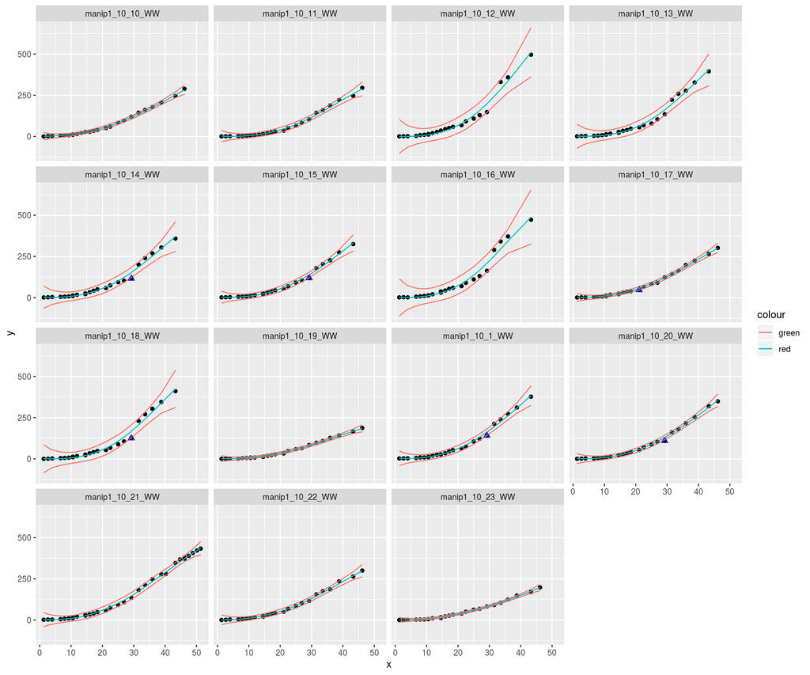

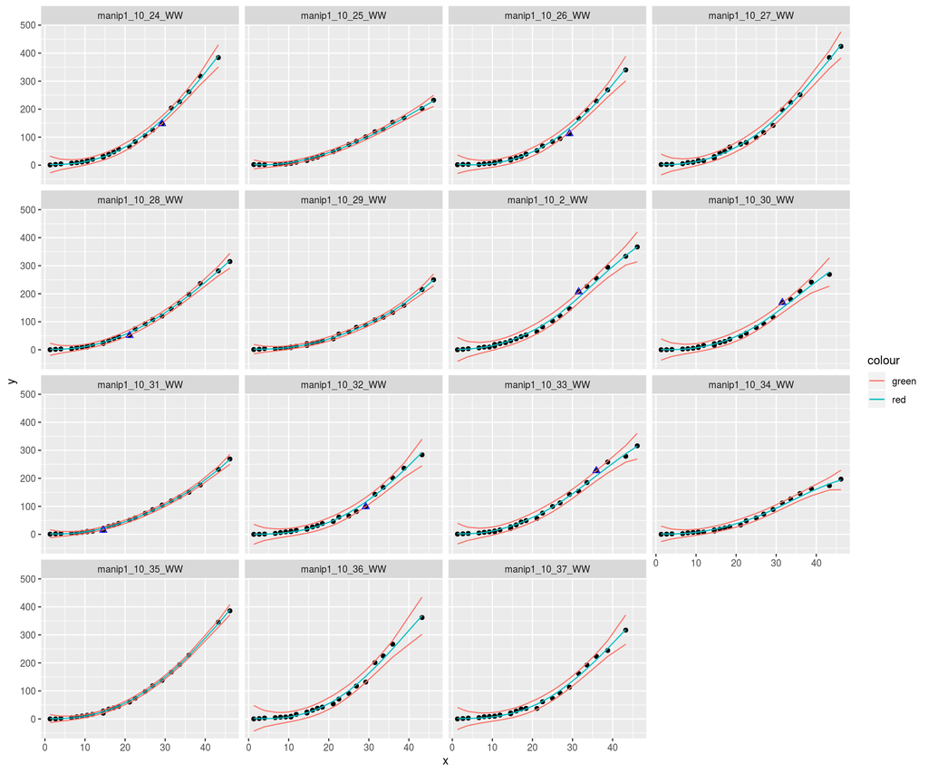

```r
  myindex<-as.character(unique(resu1[[1]][,"Ref"]))
  myindex<-myindex[1:30]
  for (i in seq(1,length(myindex),by=15)){
      myvec<-myindex[seq(i,i+14,1)]
      plotFlagPoint(smoothin=resu1[[1]],loopID="Ref",myselect=myvec)
  }
```

```r
  filter(resu1[[1]],outlier==1)
```

```
##                 Ref        x          y      ypred  ypred_se        lwr
## 1   manip1_10_14_WW 29.23635 116.065435 153.237773 3.8295043 122.601739
## 2   manip1_10_15_WW 29.23635 118.807907 138.456768 2.0872043 121.759134
## 3   manip1_10_17_WW 21.12426  46.410985  57.071447 1.2752699  46.869287
## 4   manip1_10_18_WW 29.23635 125.544827 167.409385 4.8235865 128.820694
## 5    manip1_10_1_WW 29.23635 141.210139 161.921112 2.4998685 141.922163
## 6   manip1_10_20_WW 29.23635 109.007124 129.512762 1.7011120 115.903866
## 7   manip1_10_24_WW 29.23635 148.053464 161.710921 1.6868824 148.215862
## 8   manip1_10_26_WW 29.23635 112.323684 132.338891 1.8714113 117.367600
## 9   manip1_10_28_WW 21.12426  50.966866  61.478820 1.1904833  51.954954
## 10   manip1_10_2_WW 31.53643 207.097115 186.519738 2.4032145 167.294022
## 11  manip1_10_30_WW 31.53643 168.789241 149.338587 2.2103032 131.656162
## 12  manip1_10_31_WW 14.55508  14.654266  21.641854 0.6791739  16.208463
## 13  manip1_10_32_WW 29.23635  98.670532 115.478159 2.0176402  99.337037
## 14  manip1_10_33_WW 35.94736 227.371813 208.955830 2.2650674 190.835291
```

[output cut: 1501 more lines]

# 4 Times courses with not enough points to be evaluated

```r
  # Please change the Ref column by the one in your dataframe
  if(is.null(resu1[[3]])){
    print("All the time courses have more than 4 points.")
  } else {
    ggplot(data=resu1[[3]],aes(x=x,y=y)) +
    geom_point() + facet_wrap(~Ref)
  }
```

```
## [1] "All the time courses have more than 4 points."
```

# 6 References

1. R Development Core Team (2015). R: A language and environment for statistical computing. R Foundation for Statistical Computing, Vienna, Austria. ISBN 3-900051-07-0, URL http://www.R-project.org.
2. Catherine Loader (2013). locfit: Local Regression, Likelihood and Density Estimation.. R package version 1.5-9.1. https://CRAN.R-project.org/package=locfit